# R Notebook

```r
#Loading Required packages
require(caTools)
require(rpart)
require(rattle)
require(RColorBrewer)
require(randomForest)
require(knitr)
```

```r
mydata=read.csv("d:/advertising.csv",header=TRUE)
```

```r
colnames(mydata)[which(names(mydata) == "Daily.Time.Spent.on.Site")] <- "spent"
colnames(mydata)[which(names(mydata) == "Daily.Internet.Usage")] <- "usage"
colnames(mydata)[which(names(mydata) == "Area.Income")] <- "income"
colnames(mydata)[which(names(mydata) == "Age")] <- "age"
colnames(mydata)[which(names(mydata) == "Ad.Topic.Line")] <- "topic"
colnames(mydata)[which(names(mydata) == "City")] <- "city"
colnames(mydata)[which(names(mydata) == "Male")] <- "gender"
colnames(mydata)[which(names(mydata) == "Country")] <- "country"
colnames(mydata)[which(names(mydata) == "Timestamp")] <- "timestamp"
colnames(mydata)[which(names(mydata) == "Clicked.on.Ad")] <- "clickad"
mydata$age=as.numeric(mydata$age)
mydata$gender=as.factor(mydata$gender)
mydata$clickad=as.factor(mydata$clickad)
head(mydata)
```

|  | spent | age | income | usage | topic | city | gender | country | timestamp | clickad |
| --- | --- | --- | --- | --- | --- | --- | --- | --- | --- | --- |
| 1 | 68.95 | 35 | 61833.90 | 256.09 | Cloned 5thgeneration orchestration | Wrightburgh | 0 | Tunisia | 2016-03-27 00:53:11 | 0 |
| 2 | 80.23 | 31 | 68441.85 | 193.77 | Monitored national standardization | West Jodi | 1 | Nauru | 2016-04-04 01:39:02 | 0 |
| 3 | 69.47 | 26 | 59785.94 | 236.50 | Organic bottom-line service-desk | Davidton | 0 | San Marino | 2016-03-13 20:35:42 | 0 |
| 4 | 74.15 | 29 | 54806.18 | 245.89 | Triple-buffered reciprocal time-frame | West Terrifurt | 1 | Italy | 2016-01-10 02:31:19 | 0 |
| 5 | 68.37 | 35 | 73889.99 | 225.58 | Robust logistical utilization | South Manuel | 0 | Iceland | 2016-06-03 03:36:18 | 0 |
| 6 | 59.99 | 23 | 59761.56 | 226.74 | Sharable client-driven software | Jamieberg | 1 | Norway | 2016-05-19 14:30:17 | 0 |

```r
mydata$age=as.numeric(mydata$age)
mydata$gender=as.factor(mydata$gender)
mydata$clickad=as.factor(mydata$clickad)
summary(mydata)
```

```
     spent            age            income          usage
 Min.   :32.60   Min.   :19.00   Min.   :13996   Min.   :104.8
 1st Qu.:51.36   1st Qu.:29.00   1st Qu.:47032   1st Qu.:138.8
 Median :68.22   Median :35.00   Median :57012   Median :183.1
 Mean   :65.00   Mean   :36.01   Mean   :55000   Mean   :180.0
 3rd Qu.:78.55   3rd Qu.:42.00   3rd Qu.:65471   3rd Qu.:218.8
 Max.   :91.43   Max.   :61.00   Max.   :79485   Max.   :270.0

                                     topic                  city     gender            country
 Adaptive 24hour Graphic Interface      :  1   Lisamouth      :  3   0:519   Czech Republic:  9
 Adaptive asynchronous attitude         :  1   Williamsport   :  3   1:481   France        :  9
 Adaptive context-sensitive application :  1   Benjaminchester:  2           Afghanistan   :  8
 Adaptive contextually-based methodology:  1   East John      :  2           Australia     :  8
 Adaptive demand-driven knowledgebase   :  1   East Timothy   :  2           Cyprus        :  8
 Adaptive uniform capability            :  1   Johnstad       :  2           Greece        :  8
 (Other)                                :994   (Other)        :986           (Other)       :950
               timestamp   clickad
 2016-01-01 02:52:10:  1   0:500
 2016-01-01 03:35:35:  1   1:500
 2016-01-01 05:31:22:  1
 2016-01-01 08:27:06:  1
 2016-01-01 15:14:24:  1
 2016-01-01 20:17:49:  1
 (Other)            :994
```

```r
set.seed(123)
sample = sample.split(mydata,SplitRatio = 0.8)
train=subset(mydata,sample ==TRUE)
test=subset(mydata, sample==FALSE)
```

```r
log_fit1<-glm(clickad~spent+usage+income+age+country+gender,family = "binomial",data = train)
```

```
glm.fit: fitted probabilities numerically 0 or 1 occurred
```

```r
summary(log_fit1)
```

```
Call:
glm(formula = clickad ~ spent + usage + income + age + country +
    gender, family = "binomial", data = train)

Deviance Residuals:
     Min        1Q    Median        3Q       Max
-2.56326  -0.02057   0.00000   0.01433   2.60189

Coefficients:
                                                             Estimate Std. Error z value Pr(>|z|)
(Intercept)                                                 4.590e+01  1.135e+04   0.004  0.99677
spent                                                      -2.068e-01  4.343e-02  -4.762 1.91e-06 ***
usage                                                      -9.104e-02  1.658e-02  -5.490 4.01e-08 ***
income                                                     -1.732e-04  4.449e-05  -3.893 9.89e-05 ***
age                                                         1.900e-01  5.303e-02   3.582  0.00034 ***
countryAlbania                                             -9.782e+00  1.135e+04  -0.001  0.99931
countryAlgeria                                             -9.947e+00  1.135e+04  -0.001  0.99930
countryAmerican Samoa                                      -1.622e+01  1.135e+04  -0.001  0.99886
countryAndorra                                              9.057e+00  1.902e+04   0.000  0.99962
countryAngola                                              -1.476e+01  1.135e+04  -0.001  0.99896
countryAnguilla                                            -1.235e+01  1.135e+04  -0.001  0.99913
countryAntarctica (the territory South of 60 deg S)        -1.421e+01  1.135e+04  -0.001  0.99900
countryAntigua and Barbuda                                 -7.091e+00  1.135e+04  -0.001  0.99950
countryArgentina                                           -1.441e+01  1.135e+04  -0.001  0.99899
countryArmenia                                             -1.511e+01  1.135e+04  -0.001  0.99894
countryAruba                                               -2.757e+01  3.136e+04  -0.001  0.99930
countryAustralia                                           -7.910e+00  1.135e+04  -0.001  0.99944
countryAustria                                             -1.598e+01  1.135e+04  -0.001  0.99888
countryAzerbaijan                                          -1.419e+01  1.135e+04  -0.001  0.99900
countryBahamas                                             -1.205e+01  1.135e+04  -0.001  0.99915
countryBahrain                                             -1.680e+01  1.135e+04  -0.001  0.99882
countryBangladesh                                          -1.603e+01  1.135e+04  -0.001  0.99887
countryBarbados                                            -1.455e+01  1.135e+04  -0.001  0.99898
countryBelarus                                             -1.615e+01  1.135e+04  -0.001  0.99886
countryBelgium                                             -1.697e+01  1.135e+04  -0.001  0.99881
countryBelize                                              -1.322e+01  1.135e+04  -0.001  0.99907
countryBenin                                               -1.199e+01  1.135e+04  -0.001  0.99916
countryBermuda                                             -2.518e+01  3.136e+04  -0.001  0.99936
countryBhutan                                              -9.384e+00  1.135e+04  -0.001  0.99934
countryBolivia                                             -3.030e+01  1.737e+04  -0.002  0.99861
```

[output cut: 166 more lines]

```
countrySudan                                               -2.806e+01  2.176e+04  -0.001  0.99897
countrySuriname                                             4.089e-01  3.136e+04   0.000  0.99999
countrySvalbard & Jan Mayen Islands                        -8.774e+00  1.135e+04  -0.001  0.99938
countrySwaziland                                           -2.890e+01  3.136e+04  -0.001  0.99926
 [ reached getOption("max.print") -- omitted 35 rows ]
---
Signif. codes:  0 ‘***’ 0.001 ‘**’ 0.01 ‘*’ 0.05 ‘.’ 0.1 ‘ ’ 1

(Dispersion parameter for binomial family taken to be 1)

    Null deviance: 1108.855  on 799  degrees of freedom
Residual deviance:   57.733  on 565  degrees of freedom
AIC: 527.73

Number of Fisher Scoring iterations: 20
```

Country and gender have insignificant p-value (>0.05) so we drop those columns, and fit a new logistics model

```r
log_fit2<-glm(clickad~spent+usage+income+age,family = "binomial",data = train)
summary(log_fit2)
```

```
Call:
glm(formula = clickad ~ spent + usage + income + age, family = "binomial",
    data = train)

Deviance Residuals:
    Min       1Q   Median       3Q      Max
-2.3920  -0.1413   0.0026   0.0212   3.2089

Coefficients:
              Estimate Std. Error z value Pr(>|z|)
(Intercept)  2.595e+01  2.829e+00   9.173  < 2e-16 ***
spent       -1.743e-01  2.075e-02  -8.398  < 2e-16 ***
usage       -6.594e-02  7.590e-03  -8.689  < 2e-16 ***
income      -1.283e-04  1.963e-05  -6.536 6.34e-11 ***
age          1.672e-01  2.692e-02   6.210 5.30e-10 ***
---
Signif. codes:  0 ‘***’ 0.001 ‘**’ 0.01 ‘*’ 0.05 ‘.’ 0.1 ‘ ’ 1

(Dispersion parameter for binomial family taken to be 1)

    Null deviance: 1108.86  on 799  degrees of freedom
Residual deviance:  158.73  on 795  degrees of freedom
AIC: 168.73

Number of Fisher Scoring iterations: 8
```

Looks like all the features or columns are already significant. We are going to predict the test dataset using this model.

```r
#Predict test dataset using the 2nd logistic regression model
ptest2 <- predict(log_fit2,newdata=test,type="response")
gg2=as.factor(floor(ptest2+0.5))
confusionMatrix(gg2,test$clickad)
```

```
Confusion Matrix and Statistics

          Reference
Prediction   0   1
         0 106   4
         1   0  90

               Accuracy : 0.98
                 95% CI : (0.9496, 0.9945)
    No Information Rate : 0.53
    P-Value [Acc > NIR] : <2e-16

                  Kappa : 0.9598
 Mcnemar's Test P-Value : 0.1336

            Sensitivity : 1.0000
            Specificity : 0.9574
         Pos Pred Value : 0.9636
         Neg Pred Value : 1.0000
             Prevalence : 0.5300
         Detection Rate : 0.5300
   Detection Prevalence : 0.5500
      Balanced Accuracy : 0.9787

       'Positive' Class : 0
```

This model can predict the test dataset with 0.98 accuracy. Which mean it is a good model. Next we try another algorthm: Decision Tree

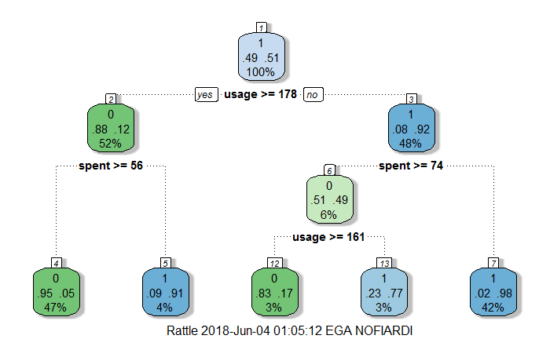

```r
#Apply Decision Tree algorithm
tree1 = rpart(clickad~spent+usage+income+age+gender, data=train, method = "class")
fancyRpartPlot(tree1)
```

```r
confusionMatrix(dttest,test$clickad)
```

```
Confusion Matrix and Statistics

          Reference
Prediction   0   1
         0 103   4
         1   3  90

               Accuracy : 0.965
                 95% CI : (0.9292, 0.9858)
    No Information Rate : 0.53
    P-Value [Acc > NIR] : <2e-16

                  Kappa : 0.9297
 Mcnemar's Test P-Value : 1

            Sensitivity : 0.9717
            Specificity : 0.9574
         Pos Pred Value : 0.9626
         Neg Pred Value : 0.9677
             Prevalence : 0.5300
         Detection Rate : 0.5150
   Detection Prevalence : 0.5350
      Balanced Accuracy : 0.9646

       'Positive' Class : 0
```

This model can predict click on ads with 96.5% accuracy. It is lower than the logistic regression model but it is still a good model too.

Next we apply another algorithm : random forest

```r
# Apply the Random Forest Algorithm
my_forest <- randomForest(clickad~spent+usage+income+age+gender, data=train, importance=TRUE,ntree=1000)
```

```r
# Make your prediction using the test set
rftest <- predict(my_forest, test)
```

```r
confusionMatrix(rftest,test$clickad)
```

```
Confusion Matrix and Statistics

          Reference
Prediction   0   1
         0 104   3
         1   2  91

               Accuracy : 0.975
                 95% CI : (0.9426, 0.9918)
    No Information Rate : 0.53
    P-Value [Acc > NIR] : <2e-16

                  Kappa : 0.9498
 Mcnemar's Test P-Value : 1

            Sensitivity : 0.9811
            Specificity : 0.9681
         Pos Pred Value : 0.9720
         Neg Pred Value : 0.9785
             Prevalence : 0.5300
         Detection Rate : 0.5200
   Detection Prevalence : 0.5350
      Balanced Accuracy : 0.9746

       'Positive' Class : 0
```

The first random forest (RF) model can predict the clicks on ads with 97.5% accuracy

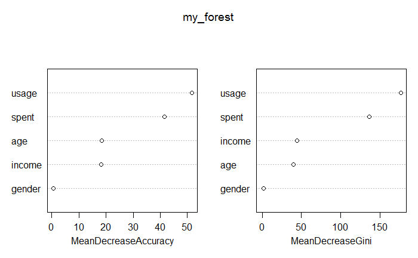

```r
varImpPlot(my_forest)
```

This plot show us which feature is important. Based on the plot, when we drop gender, it will not decrease the accuracy or the gini information. So we drop the gender to reduce the complexities of the model.

```r
# Apply the Random Forest Algorithm
my_forest2 <- randomForest(clickad~spent+income+age+usage, data=train, importance=TRUE,ntree=1000)
```

```r
# Make your prediction using the test set
rftest2 <- predict(my_forest2, test)
```

```r
confusionMatrix(rftest2,test$clickad)
```

```
Confusion Matrix and Statistics

          Reference
Prediction   0   1
         0 104   3
         1   2  91

               Accuracy : 0.975
                 95% CI : (0.9426, 0.9918)
    No Information Rate : 0.53
    P-Value [Acc > NIR] : <2e-16

                  Kappa : 0.9498
 Mcnemar's Test P-Value : 1

            Sensitivity : 0.9811
            Specificity : 0.9681
         Pos Pred Value : 0.9720
         Neg Pred Value : 0.9785
             Prevalence : 0.5300
         Detection Rate : 0.5200
   Detection Prevalence : 0.5350
      Balanced Accuracy : 0.9746

       'Positive' Class : 0
```

This model still have the same accuracy as the first algorithm. But it have less feature.

Conclusion: the best model so far is logistic regression which can predict the clicks on ads with 98% accuracy